# AB Final - Alumno: Sergio Sánchez de la Peña

## Asignatura: Advance Programming for Data Science

Se instalan en caso de que se necesite y se importan las librerías necesarias.

```r
options(reticulate.pandas_min_version = "0.0.0")
options(warn = -1)
suppressPackageStartupMessages({
  library(dplyr)
  library(quantmod)
  library(zoo)
  library(tidyr)
  library(reshape2)
  library(scales)
  library(stringr)
  library(corrplot)
  library(plotly)
})

library(ggplot2)
library(dplyr)
library(reshape2)
library(forecast)
library(zoo)
library(tidyr)
library(scales)
library(stringr)
library(corrplot)
library(plotly)
```

Primero se usa python para trabajar con ambos lenguajes:

```python
import pandas as pd

df = pd.read_csv("world_development_data_interpolated.csv")
df
```

```
##       Year           Country  ... TaxRevenue%GDP UrbanPopGrowth%
## 0     1973       Afghanistan  ...            NaN        5.688982
## 1     1973       Netherlands  ...      22.460626        1.337022
## 2     1973            Poland  ...            NaN        2.125265
## 3     1973  Egypt, Arab Rep.  ...            NaN        3.007695
## 4     1973             Gabon  ...            NaN        7.959430
## ...    ...               ...  ...            ...             ...
## 9942  2021           Hungary  ...      21.463270        0.006543
## 9943  2021        Mauritania  ...            NaN        4.000166
## 9944  2021          Kiribati  ...      27.375567        3.212155
## 9945  2021           Andorra  ...            NaN        1.636346
## 9946  2021          Zimbabwe  ...            NaN        2.234724
##
## [9947 rows x 33 columns]
```

Se pasa este df para poder trabajar con R.

```r
df<- reticulate::py$df
```

Se tiene la primera toma de contacto con el dataset:

```r
head(df)
```

|  | Year | Country | Region | SubRegion | IntermRegion | SurfAreaSqKm | PopDens | PopGrowth% | GDP | GDPGrowth% | AdolFertRate | AgriValAdd%GDP | DomCredit%GDP | Exports%GDP | FertRate | FDINetBoP | GNI/CapAtlas | GNIAtlas | GrossCapForm%GDP | Imports%GDP | IndValAdd%GDP | InflConsPric% | LifeExpBirth | MerchTrade%GDP | MilExp%GDP | MobileSubs/100 | MortRateU5 | NetMigr | PopTotal | … |
| --- | --- | --- | --- | --- | --- | --- | --- | --- | --- | --- | --- | --- | --- | --- | --- | --- | --- | --- | --- | --- | --- | --- | --- | --- | --- | --- | --- | --- | --- | --- |
| 1 | 1973 | Afghanistan | Asia | Southern Asia | NA | 652860.0 | 17.747275 | 2.5244212 | 1733333264 | NaN | 142.874 | NaN | NaN | 12.94872 | 7.487 | 270000 | NaN | NaN | 7.307692 | 14.74359 | NaN | NaN | 39.00300 | 18.17308 | 1.868910 | NaN | 285.2 | -3030 | 11575305 | … |
| 2 | 1973 | Netherlands | Europe | Western Europe | NA | 41530.0 | 398.084182 | 0.8273310 | 71840909664 | 5.444223 | 16.931 | 4.676097 | NaN | 45.41439 | 1.900 | 1118995448 | 4970 | 66754026004 | 25.746197 | 40.74563 | 31.91528 | 8.481001 | 74.14390 | 78.08364 | 2.702997 | NaN | 14.1 | 31535 | 13439322 | … |
| 3 | 1973 | Poland | Europe | Eastern Europe | NA | 312690.0 | 108.907245 | 0.9081136 | NaN | NaN | 27.951 | NaN | NaN | NaN | 2.260 | NaN | NaN | NaN | NaN | NaN | NaN | NaN | 70.66341 | NaN | NaN | NaN | 30.5 | -28055 | 33357200 | … |
| 4 | 1973 | Egypt, Arab Rep. | Africa | Northern Africa | NA | 1001450.0 | 37.290448 | 2.1511827 | 10098534613 | 3.506830 | 123.414 | 26.574931 | NaN | 13.53515 | 5.888 | 700000 | 290 | 10781692492 | 13.197398 | 18.16112 | 20.49537 | 7.352615 | 50.85200 | 20.16134 | 13.513514 | NaN | 232.5 | -112685 | 37120776 | … |
| 5 | 1973 | Gabon | Africa | Sub-Saharan Africa | Middle Africa | 267670.0 | 2.465510 | 2.0673824 | 722780701 | 10.182434 | 186.627 | 11.607697 | NaN | 58.84543 | 5.287 | 15900000 | 890 | 564468360 | 37.554314 | 57.66603 | 47.85840 | 34.757654 | 54.05700 | 72.08272 | 1.303538 | NaN | 149.4 | 613 | 635288 | … |
| 6 | 1973 | United Arab Emirates | Asia | Western Asia | NA | 98647.9 | 6.217206 | 11.8082030 | NaN | NaN | 144.822 | NaN | NaN | NaN | 6.400 | 3410000 | NaN | NaN | NaN | NaN | NaN | NaN | 63.35100 | NaN | NaN | NaN | 72.8 | 39563 | 441546 | … |

Se ven números de nulos. Se van a ver más adelante cuantos y de qué manera arreglar que R los considere todos los espacios vacíos como nulos.

```r
colSums(is.na(df))
```

```
##                Year             Country              Region           SubRegion
##                   0                   0                   0                   0
##        IntermRegion        SurfAreaSqKm             PopDens          PopGrowth%
##                5733                  47                 650                  18
##                 GDP          GDPGrowth%        AdolFertRate      AgriValAdd%GDP
##                1279                1523                   0                2451
##       DomCredit%GDP         Exports%GDP            FertRate           FDINetBoP
##                8762                2513                 201                1390
##        GNI/CapAtlas            GNIAtlas    GrossCapForm%GDP         Imports%GDP
##                2080                2079                2768                2513
##       IndValAdd%GDP       InflConsPric%        LifeExpBirth      MerchTrade%GDP
##                2502                1550                 207                1614
##          MilExp%GDP      MobileSubs/100          MortRateU5             NetMigr
##                3514                 751                 814                   0
##            PopTotal RevenueExGrants%GDP      SchEnrollPrim%      TaxRevenue%GDP
##                  17                5773                2017                5719
##     UrbanPopGrowth%
##                  18
```

```r
df[df=='']= NA

head(df)
```

|  | Year | Country | Region | SubRegion | IntermRegion | SurfAreaSqKm | PopDens | PopGrowth% | GDP | GDPGrowth% | AdolFertRate | AgriValAdd%GDP | DomCredit%GDP | Exports%GDP | FertRate | FDINetBoP | GNI/CapAtlas | GNIAtlas | GrossCapForm%GDP | Imports%GDP | IndValAdd%GDP | InflConsPric% | LifeExpBirth | MerchTrade%GDP | MilExp%GDP | MobileSubs/100 | MortRateU5 | NetMigr | PopTotal | … |
| --- | --- | --- | --- | --- | --- | --- | --- | --- | --- | --- | --- | --- | --- | --- | --- | --- | --- | --- | --- | --- | --- | --- | --- | --- | --- | --- | --- | --- | --- | --- |
| 1 | 1973 | Afghanistan | Asia | Southern Asia | NA | 652860.0 | 17.747275 | 2.5244212 | 1733333264 | NaN | 142.874 | NaN | NaN | 12.94872 | 7.487 | 270000 | NaN | NaN | 7.307692 | 14.74359 | NaN | NaN | 39.00300 | 18.17308 | 1.868910 | NaN | 285.2 | -3030 | 11575305 | … |
| 2 | 1973 | Netherlands | Europe | Western Europe | NA | 41530.0 | 398.084182 | 0.8273310 | 71840909664 | 5.444223 | 16.931 | 4.676097 | NaN | 45.41439 | 1.900 | 1118995448 | 4970 | 66754026004 | 25.746197 | 40.74563 | 31.91528 | 8.481001 | 74.14390 | 78.08364 | 2.702997 | NaN | 14.1 | 31535 | 13439322 | … |
| 3 | 1973 | Poland | Europe | Eastern Europe | NA | 312690.0 | 108.907245 | 0.9081136 | NaN | NaN | 27.951 | NaN | NaN | NaN | 2.260 | NaN | NaN | NaN | NaN | NaN | NaN | NaN | 70.66341 | NaN | NaN | NaN | 30.5 | -28055 | 33357200 | … |
| 4 | 1973 | Egypt, Arab Rep. | Africa | Northern Africa | NA | 1001450.0 | 37.290448 | 2.1511827 | 10098534613 | 3.506830 | 123.414 | 26.574931 | NaN | 13.53515 | 5.888 | 700000 | 290 | 10781692492 | 13.197398 | 18.16112 | 20.49537 | 7.352615 | 50.85200 | 20.16134 | 13.513514 | NaN | 232.5 | -112685 | 37120776 | … |
| 5 | 1973 | Gabon | Africa | Sub-Saharan Africa | Middle Africa | 267670.0 | 2.465510 | 2.0673824 | 722780701 | 10.182434 | 186.627 | 11.607697 | NaN | 58.84543 | 5.287 | 15900000 | 890 | 564468360 | 37.554314 | 57.66603 | 47.85840 | 34.757654 | 54.05700 | 72.08272 | 1.303538 | NaN | 149.4 | 613 | 635288 | … |
| 6 | 1973 | United Arab Emirates | Asia | Western Asia | NA | 98647.9 | 6.217206 | 11.8082030 | NaN | NaN | 144.822 | NaN | NaN | NaN | 6.400 | 3410000 | NaN | NaN | NaN | NaN | NaN | NaN | 63.35100 | NaN | NaN | NaN | 72.8 | 39563 | 441546 | … |

```r
colSums(is.na(df))
```

```
##                Year             Country              Region           SubRegion
##                   0                   0                   0                   0
##        IntermRegion        SurfAreaSqKm             PopDens          PopGrowth%
##                5733                  47                 650                  18
##                 GDP          GDPGrowth%        AdolFertRate      AgriValAdd%GDP
##                1279                1523                   0                2451
##       DomCredit%GDP         Exports%GDP            FertRate           FDINetBoP
##                8762                2513                 201                1390
##        GNI/CapAtlas            GNIAtlas    GrossCapForm%GDP         Imports%GDP
##                2080                2079                2768                2513
##       IndValAdd%GDP       InflConsPric%        LifeExpBirth      MerchTrade%GDP
##                2502                1550                 207                1614
##          MilExp%GDP      MobileSubs/100          MortRateU5             NetMigr
##                3514                 751                 814                   0
##            PopTotal RevenueExGrants%GDP      SchEnrollPrim%      TaxRevenue%GDP
##                  17                5773                2017                5719
##     UrbanPopGrowth%
##                  18
```

Se ha reemplado correctamente pero es mejor ver el % de NA.

```r
porcent_NA= (colSums(is.na(df))/ nrow(df))*100
sort(porcent_NA, decreasing= TRUE)
```

```
##       DomCredit%GDP RevenueExGrants%GDP        IntermRegion      TaxRevenue%GDP
##          88.0868604          58.0375993          57.6354680          57.4947220
##          MilExp%GDP    GrossCapForm%GDP         Exports%GDP         Imports%GDP
##          35.3272343          27.8274857          25.2638987          25.2638987
##       IndValAdd%GDP      AgriValAdd%GDP        GNI/CapAtlas            GNIAtlas
##          25.1533126          24.6405952          20.9108274          20.9007741
##      SchEnrollPrim%      MerchTrade%GDP       InflConsPric%          GDPGrowth%
##          20.2774706          16.2259978          15.5825877          15.3111491
##           FDINetBoP                 GDP          MortRateU5      MobileSubs/100
##          13.9740625          12.8581482           8.1833719           7.5500151
##             PopDens        LifeExpBirth            FertRate        SurfAreaSqKm
##           6.5346336           2.0810295           2.0207098           0.4725043
##          PopGrowth%     UrbanPopGrowth%            PopTotal                Year
##           0.1809591           0.1809591           0.1709058           0.0000000
##             Country              Region           SubRegion        AdolFertRate
##           0.0000000           0.0000000           0.0000000           0.0000000
##             NetMigr
##           0.0000000
```

```r
df= df[, !colnames(df) %in% c("DomCredit.GDP", "IntermRegion")]
head(df,10)
```

|  | Year | Country | Region | SubRegion | SurfAreaSqKm | PopDens | PopGrowth% | GDP | GDPGrowth% | AdolFertRate | AgriValAdd%GDP | DomCredit%GDP | Exports%GDP | FertRate | FDINetBoP | GNI/CapAtlas | GNIAtlas | GrossCapForm%GDP | Imports%GDP | IndValAdd%GDP | InflConsPric% | LifeExpBirth | MerchTrade%GDP | MilExp%GDP | MobileSubs/100 | MortRateU5 | NetMigr | PopTotal | RevenueExGrants%GDP | … |
| --- | --- | --- | --- | --- | --- | --- | --- | --- | --- | --- | --- | --- | --- | --- | --- | --- | --- | --- | --- | --- | --- | --- | --- | --- | --- | --- | --- | --- | --- | --- |
| 1 | 1973 | Afghanistan | Asia | Southern Asia | 652860.0 | 17.7472747 | 2.5244212 | 1733333264 | NaN | 142.874 | NaN | NaN | 12.94872 | 7.487 | 270000 | NaN | NaN | 7.307692 | 14.74359 | NaN | NaN | 39.00300 | 18.17308 | 1.868910 | NaN | 285.2 | -3030 | 11575305 | NaN | … |
| 2 | 1973 | Netherlands | Europe | Western Europe | 41530.0 | 398.0841825 | 0.8273310 | 71840909664 | 5.444223 | 16.931 | 4.676097 | NaN | 45.41439 | 1.900 | 1118995448 | 4970 | 66754026004 | 25.746197 | 40.74563 | 31.91528 | 8.481001 | 74.14390 | 78.08364 | 2.702997 | NaN | 14.1 | 31535 | 13439322 | 38.2941 | … |
| 3 | 1973 | Poland | Europe | Eastern Europe | 312690.0 | 108.9072448 | 0.9081136 | NaN | NaN | 27.951 | NaN | NaN | NaN | 2.260 | NaN | NaN | NaN | NaN | NaN | NaN | NaN | 70.66341 | NaN | NaN | NaN | 30.5 | -28055 | 33357200 | NaN | … |
| 4 | 1973 | Egypt, Arab Rep. | Africa | Northern Africa | 1001450.0 | 37.2904475 | 2.1511827 | 10098534613 | 3.506830 | 123.414 | 26.574931 | NaN | 13.53515 | 5.888 | 700000 | 290 | 10781692492 | 13.197398 | 18.16112 | 20.49537 | 7.352615 | 50.85200 | 20.16134 | 13.513514 | NaN | 232.5 | -112685 | 37120776 | NaN | … |
| 5 | 1973 | Gabon | Africa | Sub-Saharan Africa | 267670.0 | 2.4655101 | 2.0673824 | 722780701 | 10.182434 | 186.627 | 11.607697 | NaN | 58.84543 | 5.287 | 15900000 | 890 | 564468360 | 37.554314 | 57.66603 | 47.85840 | 34.757654 | 54.05700 | 72.08272 | 1.303538 | NaN | 149.4 | 613 | 635288 | NaN | … |
| 6 | 1973 | United Arab Emirates | Asia | Western Asia | 98647.9 | 6.2172064 | 11.8082030 | NaN | NaN | 144.822 | NaN | NaN | NaN | 6.400 | 3410000 | NaN | NaN | NaN | NaN | NaN | NaN | 63.35100 | NaN | NaN | NaN | 72.8 | 39563 | 441546 | NaN | … |
| 7 | 1973 | Viet Nam | Asia | South-eastern Asia | 331690.0 | 137.9190789 | 2.2192171 | NaN | NaN | 31.631 | NaN | NaN | NaN | 6.108 | 1030000 | NaN | NaN | NaN | NaN | NaN | NaN | 56.78600 | NaN | NaN | NaN | 79.9 | -19999 | 44891281 | NaN | … |
| 8 | 1973 | Antigua and Barbuda | Americas | Latin America and the Caribbean | 440.0 | 146.5068182 | -0.3592503 | NaN | NaN | 106.138 | NaN | NaN | NaN | 3.126 | NaN | NaN | NaN | NaN | NaN | NaN | NaN | 71.34900 | NaN | NaN | NaN | 25.0 | -1430 | 64463 | NaN | … |
| 9 | 1973 | Mongolia | Asia | Eastern Asia | 1564120.0 | 0.9062129 | 2.7819579 | NaN | NaN | 52.925 | NaN | NaN | NaN | 7.354 | NaN | NaN | NaN | NaN | NaN | NaN | NaN | 54.63100 | NaN | NaN | NaN | NaN | 4610 | 1402309 | NaN | … |
| 10 | 1973 | Haiti | Americas | Latin America and the Caribbean | 27750.0 | 179.2710450 | 1.7887867 | 466798975 | 4.755322 | 71.989 | NaN | NaN | NaN | 5.648 | 6980000 | NaN | NaN | NaN | NaN | NaN | 19.787585 | 48.20800 | 29.13460 | NaN | NaN | 227.8 | -18699 | 4940710 | NaN | … |

Se sigue con el análisis exploratorio:

```r
sapply(df, class)
```

```
##                Year             Country              Region           SubRegion
##           "numeric"         "character"         "character"         "character"
##        SurfAreaSqKm             PopDens          PopGrowth%                 GDP
##           "numeric"           "numeric"           "numeric"           "numeric"
##          GDPGrowth%        AdolFertRate      AgriValAdd%GDP       DomCredit%GDP
##           "numeric"           "numeric"           "numeric"           "numeric"
##         Exports%GDP            FertRate           FDINetBoP        GNI/CapAtlas
##           "numeric"           "numeric"           "numeric"           "numeric"
##            GNIAtlas    GrossCapForm%GDP         Imports%GDP       IndValAdd%GDP
##           "numeric"           "numeric"           "numeric"           "numeric"
##       InflConsPric%        LifeExpBirth      MerchTrade%GDP          MilExp%GDP
##           "numeric"           "numeric"           "numeric"           "numeric"
##      MobileSubs/100          MortRateU5             NetMigr            PopTotal
##           "numeric"           "numeric"           "numeric"           "numeric"
## RevenueExGrants%GDP      SchEnrollPrim%      TaxRevenue%GDP     UrbanPopGrowth%
##           "numeric"           "numeric"           "numeric"           "numeric"
```

```r
# unique(df$Country).count()
length(unique(df$Country))
```

```
## [1] 203
```

Investigo cuales hay:

```r
df$Country= trimws(df$Country)
df$Country= tolower(df$Country)
length(unique(df$Country))
```

```
## [1] 203
```

```r
unique(df$Country)
```

```
##   [1] "afghanistan"                    "netherlands"
##   [3] "poland"                         "egypt, arab rep."
##   [5] "gabon"                          "united arab emirates"
##   [7] "viet nam"                       "antigua and barbuda"
##   [9] "mongolia"                       "haiti"
##  [11] "central african republic"       "spain"
##  [13] "malaysia"                       "israel"
##  [15] "cuba"                           "saudi arabia"
##  [17] "sudan"                          "cabo verde"
##  [19] "new caledonia"                  "ethiopia"
##  [21] "argentina"                      "venezuela, rb"
##  [23] "germany"                        "turkmenistan"
##  [25] "ghana"                          "el salvador"
##  [27] "comoros"                        "slovak republic"
##  [29] "liechtenstein"                  "kenya"
```

[output cut: 87 more lines]

Se ve que hay países que no están reconocidos por la ONU. De cualquier modo, no se eliminarán, solo hay 10 países de diferencia

```r
print(table(df$Country))
```

```
##
##                    afghanistan                        albania
##                             49                             49
##                        algeria                        andorra
##                             49                             49
##                         angola            antigua and barbuda
##                             49                             49
##                      argentina                        armenia
##                             49                             49
##                          aruba                      australia
##                             49                             49
##                        austria                     azerbaijan
##                             49                             49
##                   bahamas, the                        bahrain
##                             49                             49
##                     bangladesh                       barbados
##                             49                             49
##                        belarus                        belgium
##                             49                             49
##                         belize                          benin
##                             49                             49
##                        bermuda                         bhutan
##                             49                             49
##                        bolivia         bosnia and herzegovina
##                             49                             49
##                       botswana                         brazil
##                             49                             49
##         british virgin islands              brunei darussalam
##                             49                             49
##                       bulgaria                   burkina faso
##                             49                             49
##                        burundi                     cabo verde
##                             49                             49
##                       cambodia                       cameroon
##                             49                             49
##                         canada                 cayman islands
##                             49                             49
##       central african republic                           chad
##                             49                             49
##                          chile                          china
```

[output cut: 150 more lines]

```
##                             49                             49
##                        ukraine           united arab emirates
##                             49                             49
##                 united kingdom                  united states
##                             49                             49
##                        uruguay                     uzbekistan
##                             49                             49
##                        vanuatu                  venezuela, rb
##                             49                             49
##                       viet nam             west bank and gaza
##                             49                             49
##                    yemen, rep.                         zambia
##                             49                             49
##                       zimbabwe
##                             49
```

Efectivamente, todos los países aparecen correctamente las mismas veces.

### Análisis de correlación con GDP y GDP Growth

Para la correlacion se necesita seguir limpiando el nombre de las columnas y facilitar el trabajo.

```r
colnames(df) <- gsub("\\.", "", colnames(df))
print(colnames(df))
```

```
##  [1] "Year"                "Country"             "Region"
##  [4] "SubRegion"           "SurfAreaSqKm"        "PopDens"
##  [7] "PopGrowth%"          "GDP"                 "GDPGrowth%"
## [10] "AdolFertRate"        "AgriValAdd%GDP"      "DomCredit%GDP"
## [13] "Exports%GDP"         "FertRate"            "FDINetBoP"
## [16] "GNI/CapAtlas"        "GNIAtlas"            "GrossCapForm%GDP"
## [19] "Imports%GDP"         "IndValAdd%GDP"       "InflConsPric%"
## [22] "LifeExpBirth"        "MerchTrade%GDP"      "MilExp%GDP"
## [25] "MobileSubs/100"      "MortRateU5"          "NetMigr"
## [28] "PopTotal"            "RevenueExGrants%GDP" "SchEnrollPrim%"
## [31] "TaxRevenue%GDP"      "UrbanPopGrowth%"
```

Ahora, sí se puede empezar a trabajar mejor.

```r
variables_matriz = c('GDP', 'GDPGrowth%', 'PopDens', 'AdolFertRate',
                     'AgriValAdd%GDP', 'Exports%GDP', 'FertRate', 'Imports%GDP',
                     'InflConsPric%', 'LifeExpBirth', 'MerchTrade%GDP',
                     'MortRateU5', 'NetMigr', 'PopTotal', 'RevenueExGrants%GDP',
                     'SchEnrollPrim%', 'TaxRevenue%GDP', 'UrbanPopGrowth%')

# Calculate the correlation matrix for available columns
corr_matriz = cor(df[, variables_matriz], use = "complete.obs")

# Extract correlation between GDP and GDPGrowth%
correla_gdp = corr_matriz[c("GDP", "GDPGrowth%"), ]

print(correla_gdp)
```

```
##                    GDP  GDPGrowth%     PopDens AdolFertRate AgriValAdd%GDP
## GDP         1.00000000 -0.02410214 0.001777889  -0.16829201     -0.1592868
## GDPGrowth% -0.02410214  1.00000000 0.035392856   0.09564243      0.1649491
##             Exports%GDP   FertRate Imports%GDP InflConsPric% LifeExpBirth
## GDP        -0.104180033 -0.1562306  -0.1641980   -0.01255646    0.1953931
## GDPGrowth%  0.009998372  0.1202253   0.0415861   -0.05365544   -0.1578427
##            MerchTrade%GDP MortRateU5     NetMigr  PopTotal RevenueExGrants%GDP
## GDP           -0.12780908 -0.1377159  0.41769606 0.4582532         -0.02238402
## GDPGrowth%     0.04565427  0.1327865 -0.04713344 0.1037088         -0.07670784
##            SchEnrollPrim% TaxRevenue%GDP UrbanPopGrowth%
## GDP            0.02255242    -0.06819271     -0.08855058
## GDPGrowth%     0.00359143    -0.06648686      0.17411711
```

Hay datos contradictorios debido a la falta de entendimiento de los kpis. Intento predecir el GDP.

```r
# Linear regression model to predict GDP using the other variables
gdp_model <- lm(GDP ~ PopDens + AdolFertRate + `AgriValAdd%GDP` + `Exports%GDP` +
                FertRate + `Imports%GDP` + `InflConsPric%` + LifeExpBirth +
                `MerchTrade%GDP` + MortRateU5 + NetMigr + PopTotal +
                `RevenueExGrants%GDP` + `SchEnrollPrim%` + `TaxRevenue%GDP` +
                `UrbanPopGrowth%`, data=df)

# Summary of the model
summary(gdp_model)
```

```
##
## Call:
## lm(formula = GDP ~ PopDens + AdolFertRate + `AgriValAdd%GDP` +
##     `Exports%GDP` + FertRate + `Imports%GDP` + `InflConsPric%` +
##     LifeExpBirth + `MerchTrade%GDP` + MortRateU5 + NetMigr +
##     PopTotal + `RevenueExGrants%GDP` + `SchEnrollPrim%` + `TaxRevenue%GDP` +
##     `UrbanPopGrowth%`, data = df)
##
## Residuals:
##        Min         1Q     Median         3Q        Max
## -6.072e+12 -2.562e+11 -6.804e+10  1.662e+11  1.879e+13
##
## Coefficients:
##                         Estimate Std. Error t value Pr(>|t|)
## (Intercept)           -1.509e+12  5.339e+11  -2.826 0.004741 **
## PopDens                4.876e+07  4.172e+07   1.169 0.242528
## AdolFertRate          -3.108e+09  8.700e+08  -3.572 0.000360 ***
## `AgriValAdd%GDP`      -1.504e+10  3.111e+09  -4.835 1.39e-06 ***
## `Exports%GDP`         -7.688e+09  1.789e+09  -4.298 1.78e-05 ***
## FertRate               1.695e+11  3.596e+10   4.713 2.55e-06 ***
## `Imports%GDP`          3.751e+09  1.940e+09   1.933 0.053309 .
## `InflConsPric%`        1.542e+07  8.105e+07   0.190 0.849135
## LifeExpBirth           2.597e+10  5.844e+09   4.444 9.16e-06 ***
## `MerchTrade%GDP`      -1.135e+09  9.238e+08  -1.228 0.219449
## MortRateU5            -1.064e+08  1.373e+09  -0.077 0.938241
## NetMigr                4.078e+06  1.257e+05  32.432  < 2e-16 ***
## PopTotal               4.763e+03  1.314e+02  36.259  < 2e-16 ***
## `RevenueExGrants%GDP`  1.091e+09  2.177e+09   0.501 0.616251
## `SchEnrollPrim%`       1.907e+09  1.708e+09   1.117 0.264282
## `TaxRevenue%GDP`      -1.473e+10  4.203e+09  -3.504 0.000464 ***
## `UrbanPopGrowth%`     -6.157e+10  1.693e+10  -3.637 0.000280 ***
## ---
## Signif. codes:  0 '***' 0.001 '**' 0.01 '*' 0.05 '.' 0.1 ' ' 1
##
## Residual standard error: 1.035e+12 on 3135 degrees of freedom
##   (6795 observations deleted due to missingness)
## Multiple R-squared:  0.4737, Adjusted R-squared:  0.471
## F-statistic: 176.4 on 16 and 3135 DF,  p-value: < 2.2e-16
```

El modelo no es bueno. Intentaré crear un modelo de acuerdo al GNICapAtlas.

```r
# Filtering the dataframe for the year 2021
df_2021 <- subset(df, Year == 2021)

# Sorting the filtered dataframe by GNI/CapAtlas in descending order
sorted_df_2021_GNICap <- df_2021[order(-df_2021$`GNI/CapAtlas`), ]

# Selecting the top 30 countries
top_paises_GNICap <- head(sorted_df_2021_GNICap$Country, 30)

# Displaying the names of the top 30 countries
top_paises_GNICap
```

```
##  [1] "bermuda"              "switzerland"          "luxembourg"
##  [4] "norway"               "ireland"              "united states"
##  [7] "faroe islands"        "denmark"              "cayman islands"
## [10] "iceland"              "singapore"            "qatar"
## [13] "sweden"               "australia"            "netherlands"
## [16] "hong kong sar, china" "finland"              "austria"
## [19] "germany"              "belgium"              "israel"
## [22] "canada"               "new zealand"          "macao sar, china"
## [25] "united kingdom"       "france"               "united arab emirates"
## [28] "japan"                "italy"                "korea, rep."
```

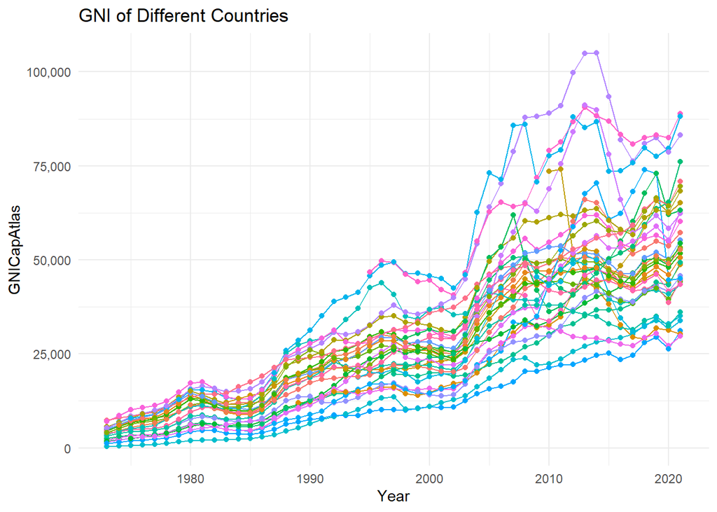

```r
countries_GDP <- df[df$Country %in% c('switzerland', 'luxembourg', 'norway', 'ireland',
                                                   'united states', 'faroe islands', 'denmark', 'cayman islands',
                                                   'iceland', 'singapore', 'qatar', 'sweden', 'australia',
                                                   'netherlands', 'hong kong sar, china', 'finland', 'austria',
                                                   'germany', 'belgium', 'israel', 'canada', 'new zealand',
                                                   'macao sar, china', 'united kingdom', 'france',
                                                   'united arab emirates', 'japan', 'italy', 'korea, rep.',
                                                   'kuwait', 'malta', 'brunei darussalam', 'spain'), ]

ggplot(data = countries_GDP, aes(x = Year, y = `GNI/CapAtlas`, color = Country)) +
  geom_line() +
  geom_point() +
  scale_y_continuous(labels = comma) +
  labs(x = 'Year', y = 'GNICapAtlas', title = 'GNI of Different Countries') +
  theme_minimal() +
  theme(legend.position = "none")
```

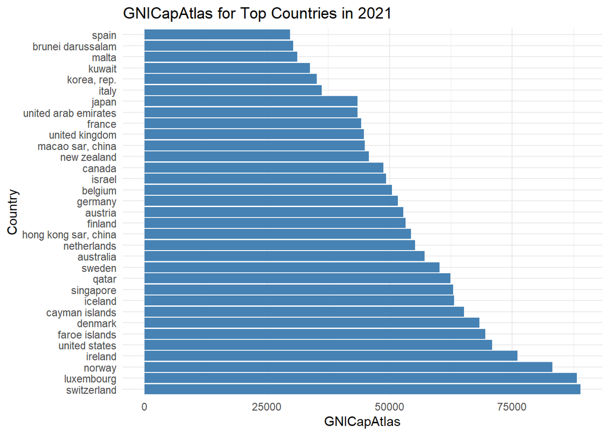

```r
df$Country <- trimws(df$Country)  # Remove leading/trailing spaces
df$Country <- tolower(df$Country)  # Convert to lowercase
df_2021$Country <- trimws(df_2021$Country)  # Remove leading/trailing spaces
df_2021$Country <- tolower(df_2021$Country)  # Convert to lowercase for consistent matching

top_paises_GNICap = df_2021[df_2021$Country %in% c('switzerland', 'luxembourg', 'norway', 'ireland',
                                                        'united states', 'faroe islands', 'denmark', 'cayman islands',
                                                        'iceland', 'singapore', 'qatar', 'sweden', 'australia',
                                                        'netherlands', 'hong kong sar, china', 'finland', 'austria',
                                                        'germany', 'belgium', 'israel', 'canada', 'new zealand',
                                                        'macao sar, china', 'united kingdom', 'france',
                                                        'united arab emirates', 'japan', 'italy', 'korea, rep.',
                                                        'kuwait', 'malta', 'brunei darussalam', 'spain'), ]

# Plotting the bar chart for GNICapAtlas
ggplot(top_paises_GNICap, aes(x = reorder(Country, -`GNI/CapAtlas`), y = `GNI/CapAtlas`)) +
  geom_bar(stat = "identity", fill = "steelblue") +
  coord_flip() +  # Flips the chart for better readability
  labs(title = "GNICapAtlas for Top Countries in 2021", x = "Country", y = "GNICapAtlas") +
  theme_minimal()
```

```r
# Replace specific country name discrepancies
df$Country <- gsub("korea, rep.", "korea, rep.", df$Country)
df$Country <- gsub("hong kong sar, china", "hong kong sar", df$Country)
df$Country <- gsub("macao sar, china", "macao sar", df$Country)
df$Country <- gsub("united states", "united states", df$Country)
df$Country <- gsub("united kingdom", "united kingdom", df$Country)
```

```r
# Select relevant numeric columns for correlation analysis
numeric_columns <- c("SurfAreaSqKm", "PopDens", "PopGrowth%", "GDP", "GDPGrowth%", "AdolFertRate",
                     "AgriValAdd%GDP", "Exports%GDP", "FertRate", "FDINetBoP",
                     "GNI/CapAtlas", "GNIAtlas", "GrossCapForm%GDP", "Imports%GDP", "IndValAdd%GDP",
                     "InflConsPric%", "LifeExpBirth", "MerchTrade%GDP", "MilExp%GDP", "MobileSubs/100",
                     "MortRateU5", "NetMigr", "PopTotal", "RevenueExGrants%GDP", "SchEnrollPrim%",
                     "TaxRevenue%GDP", "UrbanPopGrowth%")

# Filtering the dataframe for the top 30 countries across all years
# se ha excluido Bermuda porque era un valor muy extremo
top_30_countries_all_years <- df[df$Country %in% c('switzerland', 'luxembourg', 'norway', 'ireland',
                                                   'united states', 'faroe islands', 'denmark', 'cayman islands',
                                                   'iceland', 'singapore', 'qatar', 'sweden', 'australia',
                                                   'netherlands', 'hong kong sar, china', 'finland', 'austria',
                                                   'germany', 'belgium', 'israel', 'canada', 'new zealand',
                                                   'macao sar, china', 'united kingdom', 'france',
                                                   'united arab emirates', 'japan', 'italy', 'korea, rep.',
                                                   'kuwait', 'malta', 'brunei darussalam', 'spain'), ]

# Select only the relevant numeric columns for analysis
top_30_numeric_data <- top_30_countries_all_years[, numeric_columns]

# Compute the correlation matrix
correlation_matrix <- cor(top_30_numeric_data, use = "complete.obs")

# Extract correlations of GNICapAtlas with the other variables
gni_correlations <- correlation_matrix["GNI/CapAtlas", ]

# Displaying the correlation numbers
print(gni_correlations)
```

```
##        SurfAreaSqKm             PopDens          PopGrowth%                 GDP
##          0.09774781          0.05277084          0.18094622          0.19584989
##          GDPGrowth%        AdolFertRate      AgriValAdd%GDP         Exports%GDP
##         -0.23356281         -0.44687894         -0.56299684          0.31260594
##            FertRate           FDINetBoP        GNI/CapAtlas            GNIAtlas
##         -0.10915758          0.19746179          1.00000000          0.19550245
##    GrossCapForm%GDP         Imports%GDP       IndValAdd%GDP       InflConsPric%
##         -0.20641929          0.23870464         -0.34712777         -0.40860354
##        LifeExpBirth      MerchTrade%GDP          MilExp%GDP      MobileSubs/100
##          0.70635680          0.13786013         -0.34191387          0.72786982
##          MortRateU5             NetMigr            PopTotal RevenueExGrants%GDP
##         -0.59692185          0.17766053          0.04597344         -0.07584525
##      SchEnrollPrim%      TaxRevenue%GDP     UrbanPopGrowth%
##         -0.04806532         -0.11339087          0.02376464
```

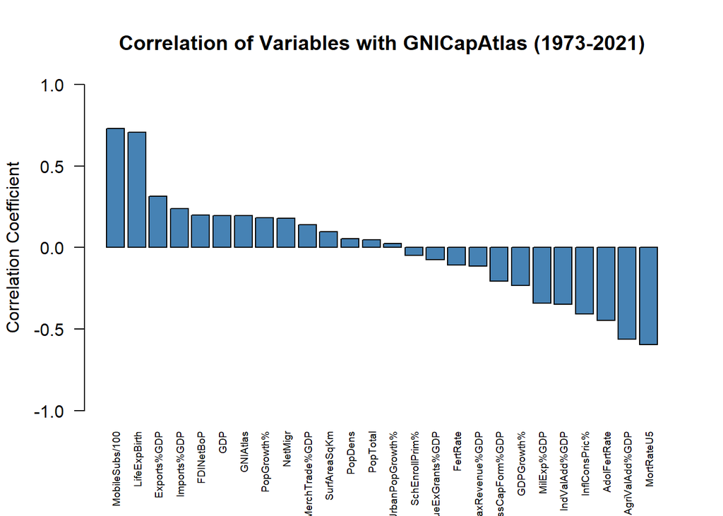

```r
# Visualizing the correlations with a bar plot (excluding GNICapAtlas itself)
gni_correlations <- gni_correlations[-which(names(gni_correlations) == "GNI/CapAtlas")]

# Plotting the correlations
barplot(sort(gni_correlations, decreasing = TRUE),
        main = "Correlation of Variables with GNICapAtlas (1973-2021)",
        col = "steelblue",
        las = 2,
        cex.names = 0.6,             # Adjust text size for better fit
        # xlab = "Variables",
        ylab = "Correlation Coefficient",
        ylim = c(-1, 1))
```

Ahora que tengo las variables que podrían predecir el crecimiento de un país, se va a hacer una regresión lineal, ya que parece que se puede adaptar bien a los datos.

```r
# Create a named vector of correlations (as per your data)
correlation_values <- c(
  SurfAreaSqKm = 0.09774781, PopDens = 0.05277084, PopGrowth = 0.18094622, GDP = 0.19584989,
  GDPGrowth = -0.23356281, AdolFertRate = -0.44687894, AgriValAddGDP = -0.56299684, ExportsGDP = 0.31260594,
  FertRate = -0.10915758, FDINetBoP = 0.19746179, GNIAtlas = 0.19550245, GrossCapFormGDP = -0.20641929,
  ImportsGDP = 0.23870464, IndValAddGDP = -0.34712777, InflConsPric = -0.40860354, LifeExpBirth = 0.70635680,
  MerchTradeGDP = 0.13786013, MilExpGDP = -0.34191387, MobileSubs100 = 0.72786982, MortRateU5 = -0.59692185,
  NetMigr = 0.17766053, PopTotal = 0.04597344, RevenueExGrantsGDP = -0.07584525, SchEnrollPrim = -0.04806532,
  TaxRevenueGDP = -0.11339087, UrbanPopGrowth = 0.02376464
)

# Use the absolute value of correlations and normalize
weights <- abs(correlation_values) / sum(abs(correlation_values))

# Display the normalized weights
weights
```

```
##       SurfAreaSqKm            PopDens          PopGrowth                GDP
##        0.014412917        0.007781062        0.026680525        0.028878071
##          GDPGrowth       AdolFertRate      AgriValAddGDP         ExportsGDP
##        0.034438842        0.065892311        0.083013898        0.046093753
##           FertRate          FDINetBoP           GNIAtlas    GrossCapFormGDP
##        0.016095288        0.029115746        0.028826841        0.030436529
##         ImportsGDP       IndValAddGDP       InflConsPric       LifeExpBirth
##        0.035197005        0.051183998        0.060248602        0.104152327
##      MerchTradeGDP          MilExpGDP      MobileSubs100         MortRateU5
##        0.020327480        0.050415208        0.107324423        0.088016141
##            NetMigr           PopTotal RevenueExGrantsGDP      SchEnrollPrim
##        0.026196049        0.006778785        0.011183384        0.007087233
##      TaxRevenueGDP     UrbanPopGrowth
##        0.016719487        0.003504097
```

```r
gni_filtered <- top_30_countries_all_years[, c("GNI/CapAtlas", numeric_columns)]

# Multiply each variable by its weight
gni_weighted_data <- gni_filtered %>%
  mutate(
    SurfAreaSqKm_weighted = SurfAreaSqKm * weights["SurfAreaSqKm"],
    PopDens_weighted = PopDens * weights["PopDens"],
    `PopGrowth%_weighted` = `PopGrowth%` * weights["PopGrowth"],
    GDP_weighted = GDP * weights["GDP"],
    `GDPGrowth%_weighted` = `GDPGrowth%` * weights["GDPGrowth"],
    AdolFertRate_weighted = AdolFertRate * weights["AdolFertRate"],
    `AgriValAdd%GDP_weighted` = `AgriValAdd%GDP` * weights["AgriValAddGDP"],
    `Exports%GDP_weighted` = `Exports%GDP` * weights["ExportsGDP"],
    FertRate_weighted = FertRate * weights["FertRate"],
    FDINetBoP_weighted = FDINetBoP * weights["FDINetBoP"],
    GNIAtlas_weighted = GNIAtlas * weights["GNIAtlas"],
    `GrossCapForm%GDP_weighted` = `GrossCapForm%GDP` * weights["GrossCapFormGDP"],
    `Imports%GDP_weighted` = `Imports%GDP` * weights["ImportsGDP"],
    `IndValAdd%GDP_weighted` = `IndValAdd%GDP` * weights["IndValAddGDP"],
    `InflConsPric%_weighted` = `InflConsPric%` * weights["InflConsPric"],
    LifeExpBirth_weighted = LifeExpBirth * weights["LifeExpBirth"],
    `MerchTrade%GDP_weighted` = `MerchTrade%GDP` * weights["MerchTradeGDP"],
    `MilExp%GDP_weighted` = `MilExp%GDP` * weights["MilExpGDP"],
    `MobileSubs/100_weighted` = `MobileSubs/100` * weights["MobileSubs100"],
    MortRateU5_weighted = MortRateU5 * weights["MortRateU5"],
    NetMigr_weighted = NetMigr * weights["NetMigr"],
    PopTotal_weighted = PopTotal * weights["PopTotal"],
    `RevenueExGrants%GDP_weighted` = `RevenueExGrants%GDP` * weights["RevenueExGrantsGDP"],
    `SchEnrollPrim%_weighted` = `SchEnrollPrim%` * weights["SchEnrollPrim"],
    `TaxRevenue%GDP_weighted` = `TaxRevenue%GDP` * weights["TaxRevenueGDP"],
    `UrbanPopGrowth%_weighted` = `UrbanPopGrowth%` * weights["UrbanPopGrowth"]
  )

# Fit the weighted regression model
weighted_lm <- lm(
  `GNI/CapAtlas` ~ `SurfAreaSqKm_weighted` + `PopDens_weighted` + `PopGrowth%_weighted` + `GDP_weighted` +
  `GDPGrowth%_weighted` + `AdolFertRate_weighted` + `AgriValAdd%GDP_weighted` + `Exports%GDP_weighted` +
  `FertRate_weighted` + `FDINetBoP_weighted` + `GNIAtlas_weighted` + `GrossCapForm%GDP_weighted` +
  `Imports%GDP_weighted` + `IndValAdd%GDP_weighted` + `InflConsPric%_weighted` + `LifeExpBirth_weighted` +
  `MerchTrade%GDP_weighted` + `MilExp%GDP_weighted` + `MobileSubs/100_weighted` + `MortRateU5_weighted` +
  `NetMigr_weighted` + `PopTotal_weighted` + `RevenueExGrants%GDP_weighted` + `SchEnrollPrim%_weighted` +
  `TaxRevenue%GDP_weighted` + `UrbanPopGrowth%_weighted`,
  data = gni_weighted_data
)
```

```r
summary(weighted_lm)
```

```
##
## Call:
## lm(formula = `GNI/CapAtlas` ~ SurfAreaSqKm_weighted + PopDens_weighted +
##     `PopGrowth%_weighted` + GDP_weighted + `GDPGrowth%_weighted` +
##     AdolFertRate_weighted + `AgriValAdd%GDP_weighted` + `Exports%GDP_weighted` +
##     FertRate_weighted + FDINetBoP_weighted + GNIAtlas_weighted +
##     `GrossCapForm%GDP_weighted` + `Imports%GDP_weighted` + `IndValAdd%GDP_weighted` +
##     `InflConsPric%_weighted` + LifeExpBirth_weighted + `MerchTrade%GDP_weighted` +
##     `MilExp%GDP_weighted` + `MobileSubs/100_weighted` + MortRateU5_weighted +
##     NetMigr_weighted + PopTotal_weighted + `RevenueExGrants%GDP_weighted` +
##     `SchEnrollPrim%_weighted` + `TaxRevenue%GDP_weighted` + `UrbanPopGrowth%_weighted`,
##     data = gni_weighted_data)
##
## Residuals:
##    Min     1Q Median     3Q    Max
## -28005  -5360   -470   4308  39001
##
## Coefficients:
##                                  Estimate Std. Error t value Pr(>|t|)
## (Intercept)                    -1.347e+05  2.847e+04  -4.730 2.72e-06 ***
## SurfAreaSqKm_weighted           9.663e-03  1.407e-02   0.687 0.492310
## PopDens_weighted                1.565e+02  7.188e+01   2.178 0.029757 *
## `PopGrowth%_weighted`          -1.743e+05  5.153e+04  -3.381 0.000762 ***
## GDP_weighted                   -4.425e-07  1.771e-07  -2.498 0.012709 *
## `GDPGrowth%_weighted`          -1.386e+04  3.784e+03  -3.662 0.000269 ***
## AdolFertRate_weighted          -6.505e+03  9.567e+02  -6.800 2.26e-11 ***
## `AgriValAdd%GDP_weighted`      -3.788e+04  4.050e+03  -9.352  < 2e-16 ***
## `Exports%GDP_weighted`          2.710e+04  1.606e+03  16.877  < 2e-16 ***
## FertRate_weighted               8.647e+05  1.009e+05   8.573  < 2e-16 ***
## FDINetBoP_weighted             -1.965e-08  2.128e-07  -0.092 0.926427
## GNIAtlas_weighted               6.259e-07  1.743e-07   3.591 0.000353 ***
## `GrossCapForm%GDP_weighted`     3.720e+04  3.830e+03   9.714  < 2e-16 ***
## `Imports%GDP_weighted`         -4.089e+04  2.460e+03 -16.621  < 2e-16 ***
## `IndValAdd%GDP_weighted`       -6.935e+03  1.491e+03  -4.653 3.92e-06 ***
## `InflConsPric%_weighted`        3.636e+03  2.403e+03   1.513 0.130703
## LifeExpBirth_weighted           1.616e+04  3.361e+03   4.809 1.86e-06 ***
## `MerchTrade%GDP_weighted`      -2.778e+03  7.962e+02  -3.489 0.000516 ***
## `MilExp%GDP_weighted`          -1.112e+05  9.686e+03 -11.482  < 2e-16 ***
## `MobileSubs/100_weighted`       9.585e+02  1.387e+02   6.911 1.09e-11 ***
## MortRateU5_weighted             1.891e+04  2.478e+03   7.631 7.67e-14 ***
## NetMigr_weighted                9.651e-01  1.407e-01   6.862 1.51e-11 ***
## PopTotal_weighted              -4.643e-02  4.709e-03  -9.860  < 2e-16 ***
## `RevenueExGrants%GDP_weighted`  1.560e+04  6.344e+03   2.459 0.014182 *
## `SchEnrollPrim%_weighted`       1.132e+04  1.354e+04   0.836 0.403300
## `TaxRevenue%GDP_weighted`      -1.315e+04  6.314e+03  -2.082 0.037700 *
## `UrbanPopGrowth%_weighted`      1.066e+06  3.255e+05   3.274 0.001114 **
## ---
## Signif. codes:  0 '***' 0.001 '**' 0.01 '*' 0.05 '.' 0.1 ' ' 1
##
## Residual standard error: 8700 on 695 degrees of freedom
##   (797 observations deleted due to missingness)
## Multiple R-squared:  0.8201, Adjusted R-squared:  0.8133
## F-statistic: 121.8 on 26 and 695 DF,  p-value: < 2.2e-16
```

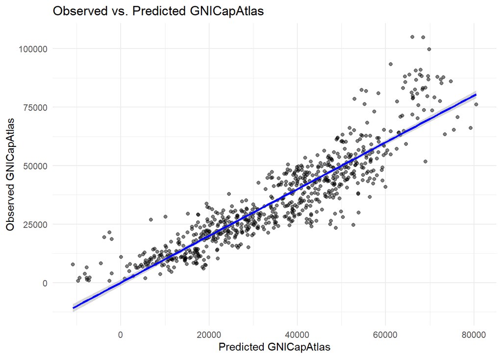

```r
library(ggplot2)
gni_weighted_data <- na.omit(gni_weighted_data)
gni_weighted_data$Predicted_GNICapAtlas <- predict(weighted_lm)


library(ggplot2)
ggplot(gni_weighted_data, aes(x = `Predicted_GNICapAtlas`, y = `GNI/CapAtlas`)) +
  geom_point(alpha = 0.5) +
  geom_smooth(method = "lm", color = "blue") +
  labs(title = "Observed vs. Predicted GNICapAtlas",
       x = "Predicted GNICapAtlas",
       y = "Observed GNICapAtlas") +
  theme_minimal()
```

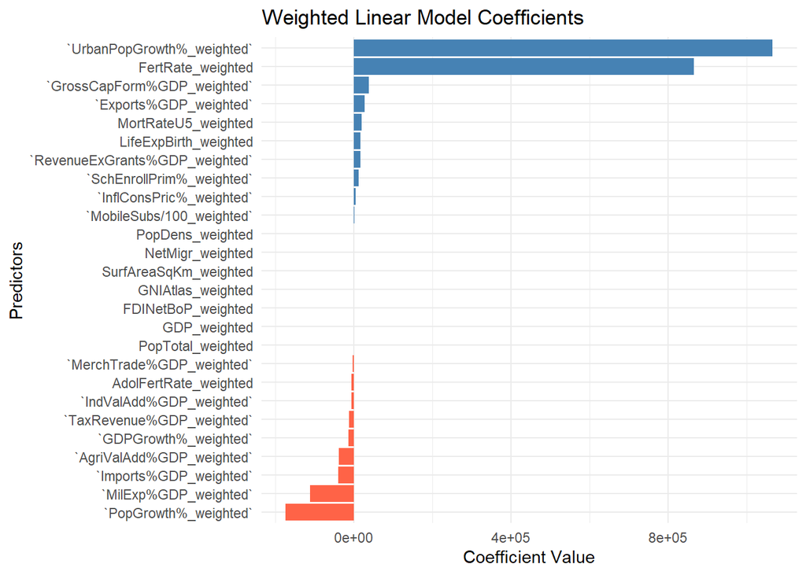

```r
# Load necessary library
library(ggplot2)
library(dplyr)

# Extract coefficients from the model
coefficients <- summary(weighted_lm)$coefficients[, 1]  # Get only the estimates
coefficients <- coefficients[-1]  # Remove intercept

# Create a data frame for plotting
coef_data <- data.frame(
  Predictor = names(coefficients),
  Coefficient = coefficients
)

# Create the bar plot
ggplot(coef_data, aes(x = reorder(Predictor, Coefficient), y = Coefficient)) +
  geom_bar(stat = "identity", fill = ifelse(coef_data$Coefficient > 0, "steelblue", "tomato")) +
  coord_flip() +  # Flip coordinates for better visibility
  labs(title = "Weighted Linear Model Coefficients",
       x = "Predictors",
       y = "Coefficient Value") +
  theme_minimal()
```

### Exponencial

```r
# Fit the exponential model
exp_lm <- lm(log(`GNI/CapAtlas`) ~ `SurfAreaSqKm_weighted` + `PopDens_weighted` +
             `PopGrowth%_weighted` + `GDP_weighted` + `GDPGrowth%_weighted` +
             `AdolFertRate_weighted` + `AgriValAdd%GDP_weighted` + `Exports%GDP_weighted` +
             `FertRate_weighted` + `FDINetBoP_weighted` + `GNIAtlas_weighted` +
             `GrossCapForm%GDP_weighted` + `Imports%GDP_weighted` + `IndValAdd%GDP_weighted` +
             `InflConsPric%_weighted` + `LifeExpBirth_weighted` + `MerchTrade%GDP_weighted` +
             `MilExp%GDP_weighted` + `MobileSubs/100_weighted` + `MortRateU5_weighted` +
             `NetMigr_weighted` + `PopTotal_weighted` + `RevenueExGrants%GDP_weighted` +
             `SchEnrollPrim%_weighted` + `TaxRevenue%GDP_weighted` + `UrbanPopGrowth%_weighted`,
             data = gni_weighted_data)

# View summary of the model
summary(exp_lm)
```

```
##
## Call:
## lm(formula = log(`GNI/CapAtlas`) ~ SurfAreaSqKm_weighted + PopDens_weighted +
##     `PopGrowth%_weighted` + GDP_weighted + `GDPGrowth%_weighted` +
##     AdolFertRate_weighted + `AgriValAdd%GDP_weighted` + `Exports%GDP_weighted` +
##     FertRate_weighted + FDINetBoP_weighted + GNIAtlas_weighted +
##     `GrossCapForm%GDP_weighted` + `Imports%GDP_weighted` + `IndValAdd%GDP_weighted` +
##     `InflConsPric%_weighted` + LifeExpBirth_weighted + `MerchTrade%GDP_weighted` +
##     `MilExp%GDP_weighted` + `MobileSubs/100_weighted` + MortRateU5_weighted +
##     NetMigr_weighted + PopTotal_weighted + `RevenueExGrants%GDP_weighted` +
##     `SchEnrollPrim%_weighted` + `TaxRevenue%GDP_weighted` + `UrbanPopGrowth%_weighted`,
##     data = gni_weighted_data)
##
## Residuals:
##      Min       1Q   Median       3Q      Max
## -0.54220 -0.14644  0.00395  0.14406  0.51963
##
## Coefficients:
##                                  Estimate Std. Error t value Pr(>|t|)
## (Intercept)                     6.968e+00  6.535e-01  10.663  < 2e-16 ***
## SurfAreaSqKm_weighted           2.543e-07  3.228e-07   0.788 0.431073
## PopDens_weighted                2.311e-03  1.650e-03   1.401 0.161678
## `PopGrowth%_weighted`          -3.207e+00  1.183e+00  -2.711 0.006869 **
## GDP_weighted                   -9.201e-12  4.065e-12  -2.263 0.023932 *
## `GDPGrowth%_weighted`          -3.115e-01  8.684e-02  -3.587 0.000359 ***
## AdolFertRate_weighted          -7.916e-02  2.196e-02  -3.605 0.000334 ***
## `AgriValAdd%GDP_weighted`      -1.299e+00  9.296e-02 -13.973  < 2e-16 ***
## `Exports%GDP_weighted`          7.038e-01  3.686e-02  19.097  < 2e-16 ***
## FertRate_weighted               1.880e+01  2.315e+00   8.122 2.09e-15 ***
## FDINetBoP_weighted              3.723e-12  4.883e-12   0.762 0.446063
## GNIAtlas_weighted               1.355e-11  4.000e-12   3.386 0.000749 ***
## `GrossCapForm%GDP_weighted`     8.779e-01  8.790e-02   9.988  < 2e-16 ***
## `Imports%GDP_weighted`         -1.142e+00  5.646e-02 -20.218  < 2e-16 ***
## `IndValAdd%GDP_weighted`       -3.802e-01  3.421e-02 -11.114  < 2e-16 ***
## `InflConsPric%_weighted`       -5.049e-03  5.516e-02  -0.092 0.927092
## LifeExpBirth_weighted           4.245e-01  7.714e-02   5.502 5.28e-08 ***
## `MerchTrade%GDP_weighted`       1.128e-02  1.827e-02   0.617 0.537136
## `MilExp%GDP_weighted`          -2.593e+00  2.223e-01 -11.665  < 2e-16 ***
## `MobileSubs/100_weighted`       1.801e-02  3.183e-03   5.657 2.26e-08 ***
## MortRateU5_weighted            -1.295e-01  5.687e-02  -2.277 0.023066 *
## NetMigr_weighted                2.396e-05  3.228e-06   7.423 3.35e-13 ***
## PopTotal_weighted              -1.152e-06  1.081e-07 -10.661  < 2e-16 ***
## `RevenueExGrants%GDP_weighted`  1.360e-01  1.456e-01   0.934 0.350541
## `SchEnrollPrim%_weighted`      -3.562e-02  3.107e-01  -0.115 0.908769
## `TaxRevenue%GDP_weighted`      -2.325e-01  1.449e-01  -1.605 0.109010
## `UrbanPopGrowth%_weighted`      1.670e+01  7.471e+00   2.236 0.025700 *
## ---
## Signif. codes:  0 '***' 0.001 '**' 0.01 '*' 0.05 '.' 0.1 ' ' 1
##
## Residual standard error: 0.1997 on 695 degrees of freedom
## Multiple R-squared:  0.9283, Adjusted R-squared:  0.9256
## F-statistic: 346.2 on 26 and 695 DF,  p-value: < 2.2e-16
```

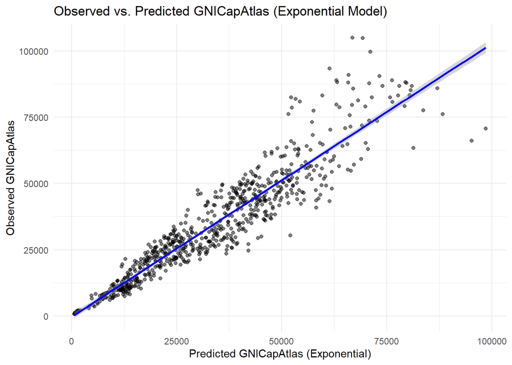

```r
# Create predictions
gni_weighted_data$Predicted_GNICapAtlas_exp <- exp(predict(exp_lm))

# Plot observed vs. predicted values
library(ggplot2)

ggplot(gni_weighted_data, aes(x = `Predicted_GNICapAtlas_exp`, y = `GNI/CapAtlas`)) +
  geom_point(alpha = 0.5) +
  geom_smooth(method = "lm", formula = y ~ x, color = "blue") +
  labs(title = "Observed vs. Predicted GNICapAtlas (Exponential Model)",
       x = "Predicted GNICapAtlas (Exponential)",
       y = "Observed GNICapAtlas") +
  theme_minimal()
```

Se hace un modelo exponencial debido a la distribución y naturaleza de los datos, viendo en la regresión lineal que se podrían ajustar más los datos. Efectivamente, es mejor modelo, tiene mejor r-squared.

## Conclusiones

Otros predictores, como GrossCapFormGDP_weighted y ExportsGDP_weighted, contribuyen de manera positiva, aunque con menor intensidad. Así como, ImportsGDP_weighted y AgriValAddGDP_weighted que tienen, en este caso, impactos negativos más moderados.

El crecimiento de la población urbana y una tasa de fertilidad adecuada son los factores más relevantes y positivos en la predicción de la calidad de vida. Esto sugiere que los países con crecimiento urbano controlado y niveles de natalidad equilibrados tienden a ofrecer mejores condiciones de vida.

Sin embargo, el gasto militar y el crecimiento de la población tienen impactos negativos, lo que podría reflejar una mala gestión de recursos o una mayor presión sobre los servicios básicos.